# Market Shocks Through Time Series Analysis

COVID-19, Trend, Volatility, Structural Breaks, and Anomalies

Devansh Sachar

2026-05-27

## Why This Topic Matters

Financial data is naturally ordered through time.

A time series approach helps us answer questions like:

- Is there a long-term trend?
- Is the series becoming more unstable?
- Did a sudden shock change the pattern?
- Are recent observations unusual?

### Case Example: COVID-19

COVID-19 is used here only as the example event.

The main focus is **time series analysis**: trend, smoothing, rolling statistics, structural breaks, and anomalies.

Simple idea: Time series analysis helps us understand how a pattern changes before, during, and after an important event.

## Presentation Roadmap

### Time Series Basics

What makes time-ordered data different from regular data?

### Trend & Smoothing

How do we see the bigger pattern behind daily noise?

### Rolling Statistics

How do we measure changing risk over time?

### Breaks & Anomalies

How do we detect unusual market behavior?

The presentation is intentionally light on finance formulas and heavier on time series concepts.

## What Is Time Series Analysis?

A **time series** is data collected in time order.

Examples:

| Area | Example |
| --- | --- |
| Market analytics | Stock returns |
| Marketing | Website traffic |
| Retail | Daily sales |
| Economics | Inflation |
| Operations | Weekly demand |

The important part is the timestamp. In time series analysis, the order of observations matters.

## Anatomy of a Time Series

Most time series can be understood using four simple pieces:

### Trend

The long-term direction of the series.

### Seasonality

A repeating pattern, such as weekly or monthly cycles.

### Cycles

Longer ups and downs caused by business or economic conditions.

### Noise

Random movement that is hard to explain.

A good analyst tries to separate signal from noise.

## Example: Trend + Seasonality + Noise

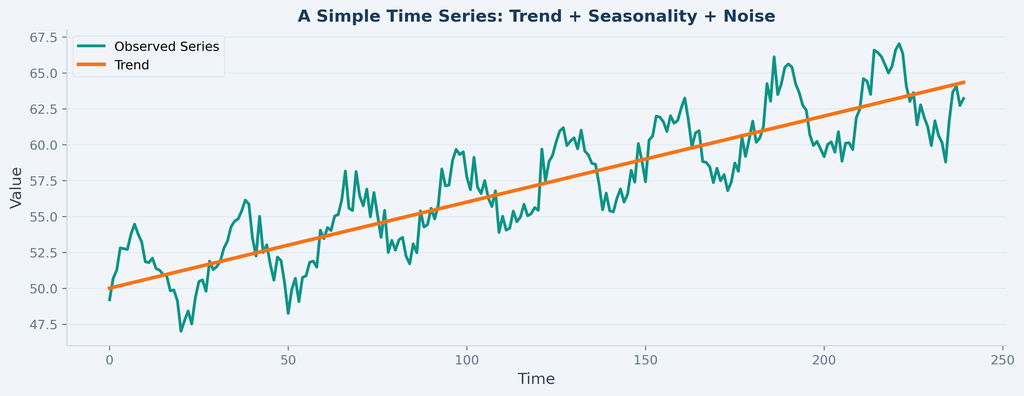

This chart is not stock data. It is a teaching example showing how a time series can contain both a smooth trend and short-term fluctuations.

## Market Index Over Time

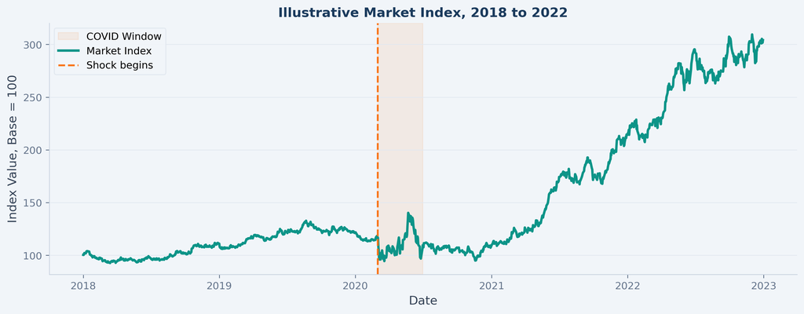

This example is simulated using Python. It is designed to make the time series concepts easy to see without needing external data files.

## Moving Average: Smoothing the Noise

A **moving average** smooths short-term ups and downs.

It helps us see the bigger direction of the series.

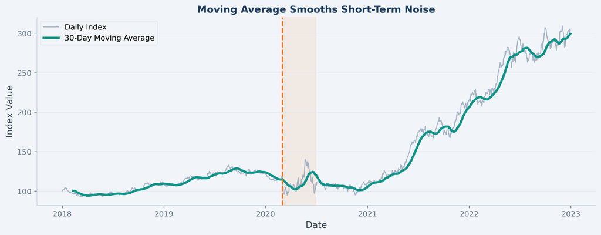

Easy explanation: the gray line is noisy daily movement. The teal line is the smoother underlying pattern.

## Prices vs Returns

For time series analysis, prices and returns answer different questions.

### Price Series

- Shows the level of the market
- Often has a trend
- Good for visual storytelling
- Less useful for measuring daily risk

### Return Series

- Shows period-to-period change
- Easier to compare across time
- Useful for volatility and anomaly detection
- Common in time series modeling

Return<sub>t</sub> = (Price<sub>t</sub> - Price<sub>t-1</sub>) / Price<sub>t-1</sub>

## Daily Returns Show the Shock More Clearly

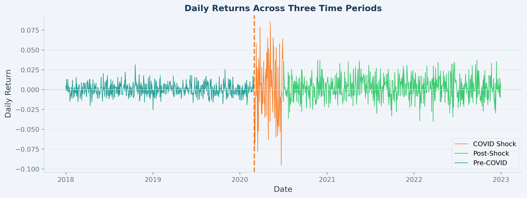

The COVID period shows larger swings. This is the first sign that the time series has changed behavior.

## Rolling Statistics

A rolling statistic recalculates a measure over a moving window.

For example, a 30-day rolling average or 30-day rolling volatility.

### Rolling Mean

Tracks the local average over time.

### Rolling Volatility

Tracks how unstable the series is over time.

### Rolling Window

Uses the most recent observations, then moves forward one day.

This is one of the most useful time series ideas because it shows that patterns are not constant.

## Rolling Volatility

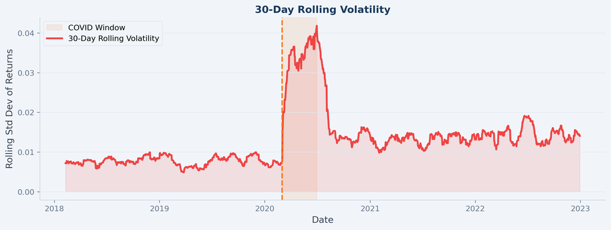

This is the key slide: volatility jumps sharply during COVID, meaning the series entered a more unstable period.

## Comparing Time Periods

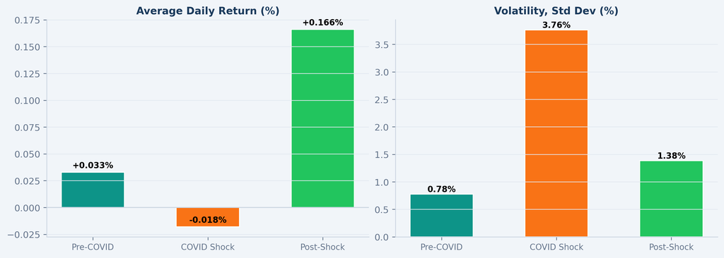

The bigger difference is not the average return. The bigger difference is the increase in volatility.

## Structural Breaks

A **structural break** happens when the behavior of a time series changes suddenly.

In simple words:

### Before

The series follows one pattern.

### Shock

A major event changes behavior.

### After

The series may follow a new pattern.

COVID can be viewed as a structural break because the volatility pattern changed suddenly around March 2020.

## Distribution of Returns

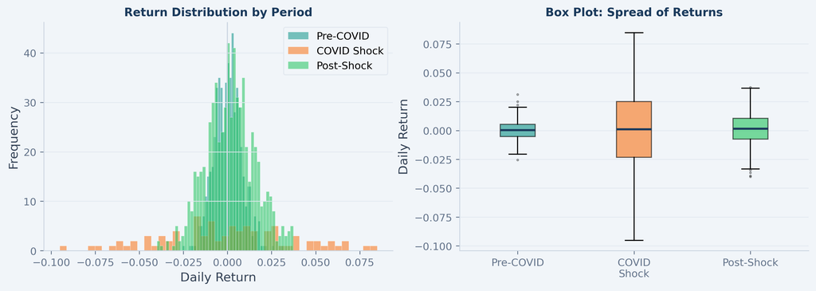

The COVID distribution is wider, meaning extreme outcomes became more common.

## Anomaly Detection

An anomaly is a data point that looks unusual compared with the normal pattern.

Simple rule used here:

Anomaly if |Return - Mean Return| > 3 × Standard Deviation

This is called the 3-sigma rule. It is simple, easy to explain, and useful for flagging unusually large movements.

## Anomaly Map

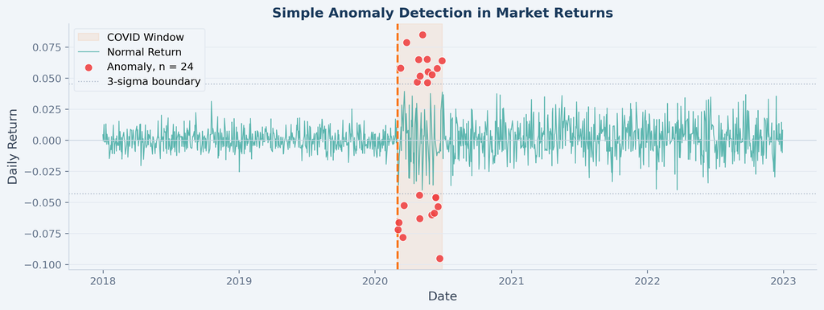

## Time Series Concepts Used

1

#### Trend

Long-term direction in the series.

2

#### Moving Average

Smooths short-term noise.

3

#### Rolling Volatility

Shows changing instability over time.

4

#### Structural Break

Detects a sudden change in behavior.

5

#### Distribution Shift

Compares how spread changes across periods.

6

#### Anomaly Detection

Flags unusually extreme observations.

## Why This Matters

Time series analysis helps decision-makers understand changing behavior.

In this example, it helps answer:

- Did the pattern change during COVID?
- Did the series become more volatile?
- Were there unusual observations?
- Did the shock create a new regime?

Main point: the value of time series analysis is not just making charts. It is understanding how behavior changes over time.

## Key Takeaways

### Time Order Matters

A time series must be analyzed in sequence because yesterday influences today.

### Smoothing Helps

Moving averages reveal the underlying pattern behind daily noise.

### Volatility Changes

Rolling volatility shows when a series becomes more unstable.

### Shocks Are Detectable

Structural breaks and anomalies help identify unusual periods.

## Final Conclusion

COVID-19 is a useful example because it shows how quickly a time series can change.

The main lesson is simple:

A time series is not just a line chart. It is a way to study trend, noise, instability, shocks, and unusual behavior over time.

By using Python, we created a simple workflow:

1. Generate a time series example
2. Smooth the trend with moving averages
3. Measure changing volatility
4. Identify structural breaks
5. Flag anomalies